# Linear Ordering of NBA Players from the Los Angeles Lakers Based on Selected Statistical Features

### **1. Summary**

This project performs a linear ordering of Los Angeles Lakers players based on selected basketball statistics. Nine diagnostic features were analyzed, including points, assists, shooting efficiency, and turnovers. The goal was to create a player ranking and evaluate the consistency of results using different data normalization methods. Destimulant variables were transformed into stimulants, and three normalization techniques were applied: unitarization, standardization, and ratio transformation. For each method, a synthetic development index (Q<sub>i</sub>) was calculated, resulting in three different rankings. The results were compared and conclusions were drawn regarding player classification.

### **2. Keywords**

Linear ordering, normalization, standardization, unitarization, ratio transformation, synthetic indicator, multivariate analysis, object ranking, stimulants, destimulants, nominants, player ranking.

### **3. Introduction**

The idea behind multivariate comparative analysis is to construct a synthetic indicator that reflects the evaluation criterion of comparable multidimensional objects. The construction of this indicator — linear ordering — depends on many factors, including the nature of the diagnostic variables, their measurement scales, the weight system, and the normalization and aggregation methods.

### **4. Subject of the Study**

#### **Objective and Scope**

The goal is to perform linear ordering of Los Angeles Lakers players by constructing a synthetic performance metric using three different normalization methods: unitarization, standardization, and ratio transformation. The study aims to create rankings and compare consistency across methods.

The analysis covers nine variables, handles missing data and outliers, and assesses data structure through descriptive statistics.

#### **Variables Selected for Analysis**

A fragment of the dataset used: <sup>[1]</sup>:

```python
import pandas as pd
df=pd.read_csv('players1.csv')
df.head()
```

|  | Rk | Player | From | To | Yrs | G | MP | FG | FGA | 3P | ... | PTS | FG% | 3P% | FT% | MP.1 | PTS.1 | TRB.1 | AST.1 | STL.1 | BLK.1 |
| --- | --- | --- | --- | --- | --- | --- | --- | --- | --- | --- | --- | --- | --- | --- | --- | --- | --- | --- | --- | --- | --- |
| 0 | 1 | Kareem Abdul-Jabbar | 1976 | 1989 | 14 | 1093 | 37492.0 | 9935 | 17520 | 1.0 | ... | 24176 | 0.567 | NaN | 0.737 | 34.3 | 22.1 | 9.4 | 3.3 | 0.9 | 2.5 |
| 1 | 2 | Tom Abernethy | 1977 | 1978 | 2 | 143 | 2695.0 | 370 | 753 | NaN | ... | 932 | 0.491 | NaN | 0.784 | 18.8 | 6.5 | 3.9 | 1.4 | 0.7 | 0.2 |
| 2 | 3 | Gary Alcorn | 1961 | 1961 | 1 | 20 | 174.0 | 12 | 40 | NaN | ... | 31 | 0.300 | NaN | 0.875 | 8.7 | 1.6 | 2.5 | 0.1 | NaN | NaN |
| 3 | 4 | Lucius Allen | 1975 | 1977 | 3 | 210 | 6881.0 | 1376 | 3045 | NaN | ... | 3351 | 0.452 | NaN | 0.773 | 32.8 | 16.0 | 3.4 | 5.1 | 1.6 | 0.3 |
| 4 | 5 | Cliff Anderson | 1968 | 1969 | 2 | 53 | 383.0 | 51 | 137 | NaN | ... | 161 | 0.372 | NaN | 0.536 | 7.2 | 3.0 | 1.0 | 0.9 | NaN | NaN |

5 rows × 30 columns

The following diagnostic features were adopted for the analysis:

| Xi | Feature | Description |
| --- | --- | --- |
| X1 | TOV (Turnovers) | Number of ball losses. |
| X2 | PTS (Points) | Total number of points scored by the player. |
| X3 | ORB (Off. Rebounds) | Offensive rebounds after missed field/free throws. |
| X4 | AST (Assists) | Total number of assists. |
| X5 | STL (Steals) | Total number of steals. |
| X6 | BLK (Blocks) | Total number of blocks. |
| X7 | FG% (Field Goals) | Percentage of successful field goals. |
| X8 | FT% (Free Throws) | Percentage of successful free throws. |
| X9 | 3P% (3-Point FG) | Percentage of successful 3-point field goals. |

The variables represent offensive, defensive, and shooting performance aspects, enabling a comprehensive player evaluation.

#### **Justification of Variables**

In the analysis of player efficiency, nine variables were selected that describe offensive and defensive aspects as well as shooting effectiveness. This allows for a comprehensive assessment of players, covering various dimensions of their activity on the court. To obtain a more reliable evaluation of player performance, data such as total points, blocks, and other statistics like assists, rebounds, or steals were averaged by the number of minutes played by the player during their career.

#### **Missing Data**

In cases where data was missing for specific player features, a simple imputation method<sup>[2]</sup> was applied — missing values were replaced with the median of the respective variable. The median, being resistant to the influence of outliers, helps preserve the distribution structure of the feature while minimizing the risk of distorting the results of the analysis.

Presentation of the total number of missing values for each column:

```python
df = df[['Player', 'Yrs', 'MP', 'ORB', 'AST', 'STL', 'BLK', 'TOV', 'PTS', 'FG%', '3P%', 'FT%']]
print(df.isna().sum())
```

```
Player      0
Yrs         0
MP         20
ORB       117
AST         0
STL       117
BLK       117
TOV       147
PTS         0
FG%         3
3P%       215
FT%        25
dtype: int64
```

Total number of players in the dataset:

```python
print(len(df))
```

```
506
```

```python
def preprocess_data(df, all_features):
    df = df[df['Yrs'] > 1]

    df = df[df['MP'].notna()]
    df[all_features] = df[all_features].fillna(df[all_features].median())

    per_minute_features = ['ORB', 'AST', 'STL', 'BLK', 'TOV', 'PTS']
    for feature in per_minute_features:
        df[feature] = df[feature] / df['MP']

    return df
```

Total number of players in the dataset after data selection:

```python
features = ['ORB', 'AST', 'STL', 'BLK', 'TOV', 'PTS', 'FG%', '3P%', 'FT%']
df = preprocess_data(df, features)
print(len(df))
df.head()
```

```
229
```

|  | Player | Yrs | MP | ORB | AST | STL | BLK | TOV | PTS | FG% | 3P% | FT% |
| --- | --- | --- | --- | --- | --- | --- | --- | --- | --- | --- | --- | --- |
| 0 | Kareem Abdul-Jabbar | 14 | 37492.0 | 0.066521 | 0.097407 | 0.026219 | 0.071855 | 0.067401 | 0.644831 | 0.567 | 0.313 | 0.737 |
| 1 | Tom Abernethy | 2 | 2695.0 | 0.080891 | 0.073840 | 0.038590 | 0.011874 | 0.018553 | 0.345826 | 0.491 | 0.313 | 0.784 |
| 3 | Lucius Allen | 3 | 6881.0 | 0.029502 | 0.157099 | 0.049266 | 0.009737 | 0.022380 | 0.486993 | 0.452 | 0.313 | 0.773 |
| 4 | Cliff Anderson | 2 | 383.0 | 0.352480 | 0.125326 | 0.229765 | 0.107050 | 0.402089 | 0.420366 | 0.372 | 0.313 | 0.536 |
| 5 | Kostas Antetokounmpo | 2 | 76.0 | 0.078947 | 0.039474 | 0.026316 | 0.052632 | 0.157895 | 0.250000 | 0.462 | 0.313 | 0.467 |

#### **Outliers and Their Handling**

The Interquartile Range (IQR) method<sup>[3]</sup> was applied. Based on the quartiles Q1 (25th percentile) and Q3 (75th percentile), the IQR, which is a measure of data dispersion, was calculated. The boundaries for outlying observations were computed as follows:

- Lower boundary = Q1 - 1.5 × IQR
- Upper boundary = Q3 + 1.5 × IQR

Observations that fall outside this range were considered outliers.

Below is the identification of outliers for the BLK feature:

```python
def find_outliers_IQR(df):
   q1=df.quantile(0.25)
   q3=df.quantile(0.75)
   IQR=q3-q1
   outliers = df[((df<(q1-1.5*IQR)) | (df>(q3+1.5*IQR)))]
   return outliers

outliers = find_outliers_IQR(df['BLK'])

print('Number of outliers: '+ str(len(outliers)))
print('Max outlier value: '+ str(outliers.max()))
print('Min outlier value: '+ str(outliers.min()))
```

```
Number of outliers: 20
Max outlier value: 0.29927007299270075
Min outlier value: 0.056708160442600276
```

```python
df.describe()['BLK']
```

```
count    229.000000
mean       0.022857
std        0.033369
min        0.000000
25%        0.005694
50%        0.012611
75%        0.024939
max        0.299270
Name: BLK, dtype: float64
```

Subsequently, for each feature, outlier values were replaced with the mean for the respective column. This was done to minimize the impact of extreme observations on further analysis. As a result of this process, the data became more representative, and the analysis results were less sensitive to potential measurement errors or atypical observations.

```python
def impute_outliers_IQR(df, features):

    for feature in features:
        q1 = df[feature].quantile(0.25)
        q3 = df[feature].quantile(0.75)
        IQR = q3 - q1

        lower_bound = q1 - 1.5 * IQR
        upper_bound = q3 + 1.5 * IQR
        mean_val = df[feature].mean()

        df.loc[df[feature] > upper_bound, feature] = mean_val
        df.loc[df[feature] < lower_bound, feature] = mean_val

    return df

df = impute_outliers_IQR(df, features)

df.describe()['BLK']
```

```
count    229.000000
mean       0.015848
std        0.012387
min        0.000000
25%        0.005694
50%        0.012611
75%        0.022857
max        0.053748
Name: BLK, dtype: float64
```

Above, the characteristic of the BLK feature is presented after handling the outlying observations.

#### **Numerical Characteristics of Diagnostic Features Presented in the Table:**

[output not shown]

**Conclusions:**

The features with the least variability are:

This indicates a relative homogeneity of these variables in the analyzed sample.

#### **Division into Stimuli, Detractors, and Nominals**

When performing the ranking, features are divided into 3 groups based on preferences:

- **stimuli**, where higher values of this feature classify the object as "better",
- **detractors**, where higher values of this feature classify the object as "worse",
- **nominals**, where the normal level gives the object a "higher" position, and deviations from this level result in a "lower" position.

| Stimuli | Detractors |
| --- | --- |
| PTS | TOV |
| ORB |  |
| AST |  |
| STL |  |
| BLK |  |
| FG% |  |
| FT% |  |
| 3P% |  |

Features such as **ORB** (offensive rebounds), **AST** (assists), **STL** (steals), **BLK** (blocks), **PTS** (points), **FG%** (field goal percentage), **3P%** (three-point percentage), and **FT%** (free throw percentage) are stimuli, as they directly impact the improvement of the team's performance, enabling them to score points, improve defense, and transition effectively to offense. On the other hand, **TOV** (turnovers) is a detractor, as each turnover by a player negatively affects their statistics.

In research, it is usually required that all features be stimuli. Detractors can then be transformed into stimuli using a differential formula:

$$ \Large x_{ij}^S = max_{i}(x_{ij}) - x_{ij}^D $$

where:

- *i* – object number
- *j* – variable number
- *x<sub>ij</sub>* – the value being studied (i.e., the j-th feature of the i-th object)

```python
def transform_destimulants(df, destimulants):
    for feature in destimulants:
        df[feature] = df[feature].max() - df[feature]
    return df

df = transform_destimulants(df, ['TOV'])
```

### **5. Distribution Plots of Feature Values**

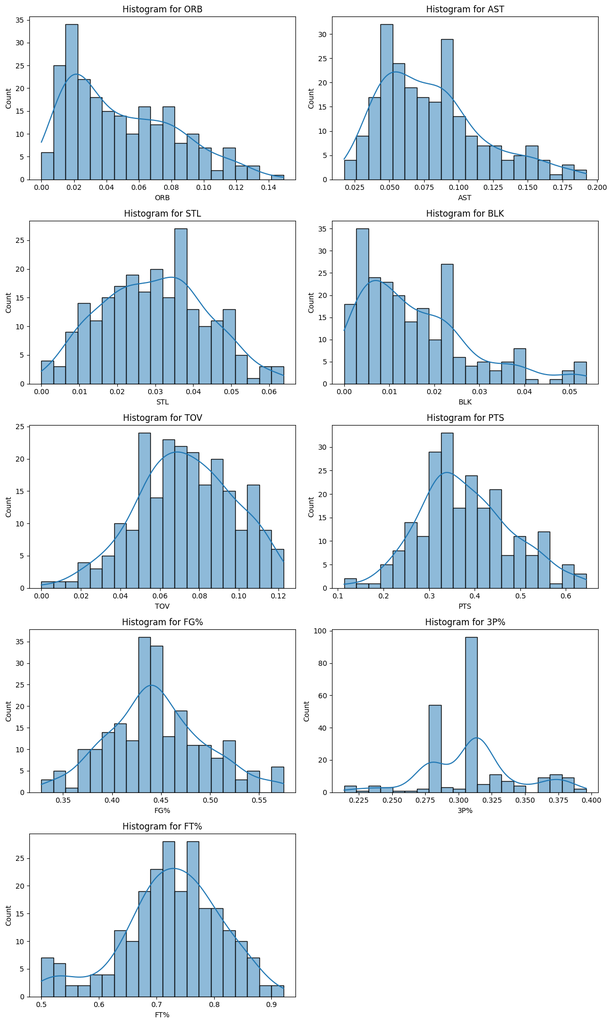

```python
import matplotlib.pyplot as plt
import seaborn as sns
import math

def plot_histograms(df, features):
    num_features = len(features)
    num_rows = math.ceil(num_features / 2)

    fig, axs = plt.subplots(num_rows, 2, figsize=(12, 4 * num_rows))
    axs = axs.flatten()

    for i, feature in enumerate(features):
        sns.histplot(df[feature], kde=True, bins=20, ax=axs[i])
        axs[i].set_title(f'Histogram for {feature}')

    for j in range(i + 1, len(axs)):
        fig.delaxes(axs[j])

    plt.tight_layout()
    plt.show()

plot_histograms(df, features)
```

### **6. Normalization of Variables**

When creating a ranking of objects based on quantitative features, it is necessary to normalize the variables.

Normalization refers to "standardizing or standardizing feature values from the perspective of a specific criterion." The main goal of this type of transformation is to satisfy the additivity requirement, meaning bringing features with different units of measurement into a comparable form. There are numerous methods for normalizing quantitative features<sup>[4]</sup>. Within a given normalization formula, there are simple formulas that standardize the characteristics of variables.

Selected methods of normalization:

- Unit normalization
- Standardization
- Ratio transformation
1. **Unit normalization (MUZ method)**

   In this method, the variances and means of the variables (features) remain different, but all of these features will take values within the convenient computation interval [0, 1]. The transformed variables behave as stimuli (values closer to 1 indicate the best values of the selected diagnostic variables):

   $$ \Large z_{ij} = \frac{x_{ij} - \min_i(x_{ij})}{\max_i(x_{ij}) - \min_i(x_{ij})} $$

   Thus, the smallest value in the dataset is subtracted from the value being studied (i.e., the j-th feature of the i-th object, e.g., shooting efficiency), and the result is divided by the range, i.e., the difference between the maximum and minimum values.

```python
def min_max_scaling(df, features):
    df_norm = df.copy()
    df_norm[features] = (df_norm[features] - df_norm[features].min()) / (df_norm[features].max() - df_norm[features].min())
    return df_norm

normalized_df = min_max_scaling(df, features)
normalized_df = normalized_df.drop(['Yrs', 'MP'], axis=1)

normalized_df.head()
```

|  | Player | ORB | AST | STL | BLK | TOV | PTS | FG% | 3P% | FT% |
| --- | --- | --- | --- | --- | --- | --- | --- | --- | --- | --- |
| 0 | Kareem Abdul-Jabbar | 0.445992 | 0.457710 | 0.410906 | 0.425266 | 0.484765 | 1.000000 | 0.967611 | 0.543956 | 0.562945 |
| 1 | Tom Abernethy | 0.542334 | 0.322952 | 0.604787 | 0.220919 | 0.883060 | 0.437108 | 0.659919 | 0.543956 | 0.674584 |
| 3 | Lucius Allen | 0.197794 | 0.799031 | 0.772105 | 0.181161 | 0.851851 | 0.702863 | 0.502024 | 0.543956 | 0.648456 |
| 4 | Cliff Anderson | 0.403973 | 0.617352 | 0.589303 | 0.425266 | 0.445185 | 0.577433 | 0.178138 | 0.543956 | 0.085511 |
| 5 | Kostas Antetokounmpo | 0.529306 | 0.126441 | 0.412425 | 0.979238 | 0.445185 | 0.256711 | 0.542510 | 0.543956 | 0.523354 |

2. **Standardization**

   Standardization transforms the features so that they have a variance equal to 1 and a mean equal to 0. Some numbers will change from positive to negative (which is possible, as shown by the numerator of the fraction: this occurs when a value is smaller than the mean).

   All values x<sub>ij</sub> are transformed in this way, provided they are stimuli: $$ \Large z_{ij} = \frac{x_{ij} - \overline{x}_j}{S(x_j)} \quad i = 1, 2, \dots, n; \quad j = 1, 2, \dots, m $$

   Here, x‾<sub>j</sub> represents the arithmetic mean of the j-th variable, and S(x<sub>j</sub>) denotes the standard deviation of that same j-th variable.

```python
def standardization(df, features):
    df_norm = df.copy()
    df_norm[features] = (df_norm[features] - df_norm[features].mean()) / df_norm[features].std()
    return df_norm

normalized_df = standardization(df, features)
normalized_df = normalized_df.drop(['Yrs', 'MP'], axis=1)

normalized_df.head()
```

|  | Player | ORB | AST | STL | BLK | TOV | PTS | FG% | 3P% | FT% |
| --- | --- | --- | --- | --- | --- | --- | --- | --- | --- | --- |
| 0 | Kareem Abdul-Jabbar | 0.518031 | 0.461095 | -0.252371 | 0.565869 | -0.567774 | 2.608527 | 2.427531 | 0.082782 | 0.124200 |
| 1 | Tom Abernethy | 0.950888 | -0.171546 | 0.651562 | -0.320827 | 1.429061 | -0.343159 | 0.907564 | 0.082782 | 0.669740 |
| 3 | Lucius Allen | -0.597100 | 2.063484 | 1.431648 | -0.493343 | 1.272595 | 1.050403 | 0.127581 | 0.082782 | 0.542060 |
| 4 | Cliff Anderson | 0.329244 | 1.210561 | 0.579370 | 0.565869 | -0.766209 | 0.392676 | -1.472383 | 0.082782 | -2.208854 |
| 5 | Kostas Antetokounmpo | 0.892354 | -1.094099 | -0.245293 | 2.969646 | -0.766209 | -1.289119 | 0.327577 | 0.082782 | -0.069271 |

3. **Ratio Transformation with the Mean as the Basis for Normalization**

   In this method, each feature value is compared to the arithmetic mean of that feature. As a result, we obtain values expressed as a proportion relative to the mean. This allows us to assess how much a given value deviates from the "typical" level. The formula is as follows:

   $$ \Large z_{ij} = \frac{x_{ij}}{\overline{x}_j} $$

   Here, x‾<sub>j</sub> represents the arithmetic mean of the j-th variable, and x<sub>ij</sub> represents the j-th feature of the i-th object.

```python
def ratio_transformation(df, features):
    df_norm = df.copy()
    df_norm[features] = df_norm[features].div(df_norm[features].mean())

    return df_norm

normalized_df = ratio_transformation(df, features)

normalized_df.head()
```

|  | Player | Yrs | MP | ORB | AST | STL | BLK | TOV | PTS | FG% | 3P% | FT% |
| --- | --- | --- | --- | --- | --- | --- | --- | --- | --- | --- | --- | --- |
| 0 | Kareem Abdul-Jabbar | 14 | 37492.0 | 1.348661 | 1.214090 | 0.883601 | 1.442282 | 0.810624 | 1.694304 | 1.272382 | 1.009292 | 1.014733 |
| 1 | Tom Abernethy | 2 | 2695.0 | 1.639996 | 0.920350 | 1.300516 | 0.749242 | 1.476652 | 0.908662 | 1.101834 | 1.009292 | 1.079444 |
| 3 | Lucius Allen | 3 | 6881.0 | 0.598122 | 1.958091 | 1.660310 | 0.614405 | 1.424464 | 1.279582 | 1.014315 | 1.009292 | 1.064299 |
| 4 | Cliff Anderson | 2 | 383.0 | 1.221598 | 1.562073 | 1.267219 | 1.442282 | 0.744437 | 1.104517 | 0.834790 | 1.009292 | 0.737987 |
| 5 | Kostas Antetokounmpo | 2 | 76.0 | 1.600599 | 0.492001 | 0.886865 | 3.321066 | 0.744437 | 0.656879 | 1.036756 | 1.009292 | 0.991783 |

### **7. Construction of the Synthetic Indicator**

The calculation of the aggregate variable Q<sub>i</sub> using the formula below serves as the basis for constructing a ranking of players based on their statistics. The indicator is built using the method of summing normalized variables. The results obtained depend on the selected normalization formulas.

$$ \Large Q_i = \sum_{j=1}^{k} a_j z_{ij} $$

where:

- *i* – object number
- *j* – variable number
- *a<sub>j</sub>* – weight for the given variable
- *z<sub>ij</sub>* – normalized value of variable *j* for object *i*
- *Q<sub>i</sub>* – synthetic indicator for the given object

The higher the value of the synthetic variable Q<sub>i</sub>, the higher the object ranks.

```python
def compute_synthetic_index(df, weights=None):
    if weights is None:
        weights = np.ones(df.shape[1]) / df.shape[1]
    return df.dot(weights)
```

### **8. Rankings Based on the Value of the Synthetic Indicator**

#### **8.1 Unitarization**

```python
from IPython.display import display, HTML

def generate_rankings(df, all_features, method):
    df_norm = method(df.copy(), all_features)
    df["Synthetic_Index"] = compute_synthetic_index(df_norm[all_features])
    ranking = df[["Player", "Synthetic_Index"]].sort_values(by="Synthetic_Index", ascending=False)
    return ranking

ranking_df = generate_rankings(df, features, min_max_scaling)

top10 = ranking_df.head(10)
bottom10 = ranking_df.tail(10)

display(HTML(f"""
<div style="display: inline-block; vertical-align: top;">
    <h3>Top 10 players</h3>
    {top10.to_html(index=False)}
</div>
<div style="display: inline-block; margin-left: 30px; vertical-align: top;">
    <h3>Last 10 players</h3>
    {bottom10.to_html(index=False)}
</div>
"""))
```

Top 10 players

| Player | Synthetic_Index |
| --- | --- |
| Flynn Robinson | 0.703491 |
| Devontae Cacok | 0.621661 |
| Earl Tatum | 0.600642 |
| Kareem Abdul-Jabbar | 0.588795 |
| Eddie Jones | 0.584669 |
| Lucius Allen | 0.577693 |
| Connie Hawkins | 0.577285 |
| Jim Price | 0.573569 |
| Sedale Threatt | 0.565329 |
| Ivica Zubac | 0.565298 |

Last 10 players

| Player | Synthetic_Index |
| --- | --- |
| Jim Holstein | 0.338420 |
| Tom Hawkins | 0.336689 |
| Vander Blue | 0.336405 |
| Marcelo Huertas | 0.331595 |
| Travis Grant | 0.319341 |
| Aaron McKie | 0.312368 |
| Eddie Jordan | 0.304926 |
| Gene Wiley | 0.304414 |
| Maxwell Lewis | 0.274849 |
| Adam Morrison | 0.273079 |

```python
ranking_df = generate_rankings(df, features, min_max_scaling)

top10 = ranking_df.head(10)
bottom10 = ranking_df.tail(10)

display(HTML(f"""
<div style="display: inline-block; vertical-align: top;">
    <h3>Top 10 players</h3>
    {top10.to_html(index=False)}
</div>
<div style="display: inline-block; margin-left: 30px; vertical-align: top;">
    <h3>Last 10 players</h3>
    {bottom10.to_html(index=False)}
</div>
"""))
```

Top 10 players

[output not shown]

Last 10 players

[output not shown]

#### **8.3 Ratio Transformation with the Mean as the Basis for Normalization**

```python
ranking_df = generate_rankings(df, features, ratio_transformation)

top10 = ranking_df.head(10)
bottom10 = ranking_df.tail(10)

display(HTML(f"""
<div style="display: inline-block; vertical-align: top;">
    <h3>Top 10 players</h3>
    {top10.to_html(index=False)}
</div>
<div style="display: inline-block; margin-left: 30px; vertical-align: top;">
    <h3>Last 10 players</h3>
    {bottom10.to_html(index=False)}
</div>
"""))
```

Top 10 players

| Player | Synthetic_Index |
| --- | --- |
| Flynn Robinson | 1.526888 |
| Vlade Divac | 1.383170 |
| Devontae Cacok | 1.366591 |
| Kermit Washington | 1.339179 |
| Jim Brewer | 1.334621 |
| Ivica Zubac | 1.278960 |
| Travis Knight | 1.270178 |
| Connie Hawkins | 1.268492 |
| Earl Tatum | 1.261204 |
| Jemerrio Jones | 1.257127 |

Last 10 players

| Player | Synthetic_Index |
| --- | --- |
| Jim Krebs | 0.754093 |
| Vander Blue | 0.752138 |
| Sam Jacobson | 0.751932 |
| Leroy Ellis | 0.749817 |
| Andrew Goudelock | 0.739923 |
| Eddie Jordan | 0.739657 |
| Tom Hawkins | 0.738424 |
| Gene Wiley | 0.719720 |
| Maxwell Lewis | 0.691346 |
| Travis Grant | 0.605561 |

### **9. Summary**

### **Players appearing in the TOP 10 across all three methods:**

**Number of such players:** 4

- Flynn Robinson
- Devontae Cacok
- Earl Tatum
- Connie Hawkins

#### **Players with the same ranking position in all three methods:**

**Number of such players:** 1

- Flynn Robinson

#### **Players with identical positions in two rankings (normalization and unitarization):**

**Number of such players:** 23

- Flynn Robinson
- Devontae Cacok
- Earl Tatum
- Kareem Abdul-Jabbar
- Eddie Jones
- Lucius Allen
- Tom Abernethy
- James Worthy
- Don Ford
- Tony Campbell
- Bob Harrison
- Freddie Crawford
- Willie McCarter
- James Edwards
- Ronnie Lester
- Whitey Skoog
- Rajon Rondo
- Jalen Hood-Schifino
- Antonio Harvey
- Vander Blue
- Marcelo Huertas
- Travis Grant
- Aaron McKie

### **10. Conclusions:**

#### **Ranking Consistency**

Four players who appeared in the **TOP 10** across all three methods are **Flynn Robinson, Devontae Cacok, Earl Tatum, and Connie Hawkins**. This indicates that these players maintain high positions regardless of the transformation method used, which suggests their stable performance across all normalization techniques.

#### **Impact of the Normalization Method**

The analysis shows that changing the data transformation method (e.g., standardization, unitarization, ratio transformation) can affect the ranking outcomes of players, even though the structure of the data remains unchanged.

1. **Standardization and unitarization yield more similar results**

For **23 players** who held identical positions in the rankings after **normalization** and **unitarization**, we observe that these two transformation methods produce similar outcomes for most players. This may be because both methods largely preserve the proportions between the values of the statistics.

2. **Ratio Transformation Causes Greater Divergence**

**Ratio transformation** is more sensitive to **changes in the proportions** between statistics. **Flynn Robinson** is the only player who maintained the same position in all three rankings, which shows that the ratio method has a greater impact on changing player positions in the ranking.

#### **Limitations of the Analysis**

- The ranking is based solely on the available numerical data and does not take into account contextual factors, such as the player's role in the team or injuries. Additionally, the selection of specific diagnostic variables and their weight in the analysis can significantly influence the final result.

### **11. Performance Evaluation**

In summary, the analysis not only allowed for the creation of rankings that order players based on their performance but also identified the differences resulting from the choice of a specific data transformation method.

### **12. References**

[1] *https://www.basketball-reference.com/teams/LAL/players.html*  
[2] *https://drizzt.home.amu.edu.pl/images/DADA_AIPD/W3.pdf*  
[3] *https://en.wikipedia.org/wiki/Interquartile_range*  
[4] *Jarocka M., Wybór formuły normalizacyjnej w analizie porównawczej obiektów wielocechowych, Politechnika Białostocka, Wydział Zarządzania, Katedra Informatyki Gospodarczej i Logistyki*

### **13. Code**

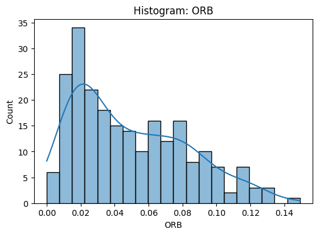

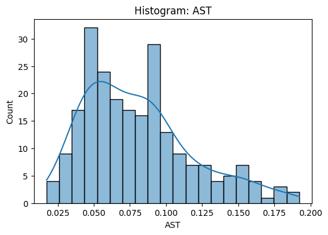

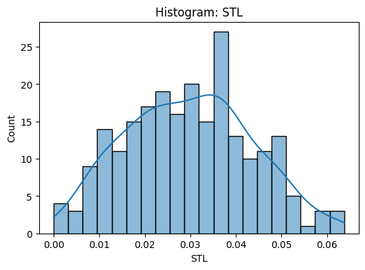

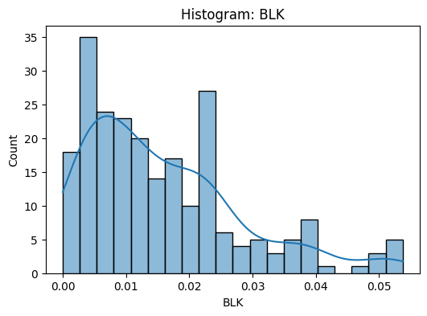

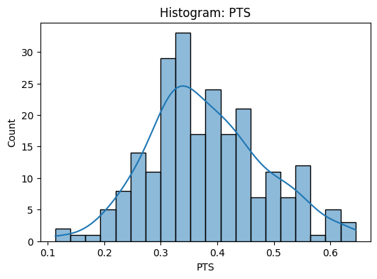

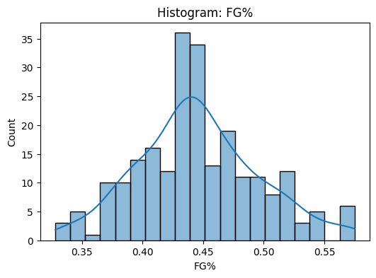

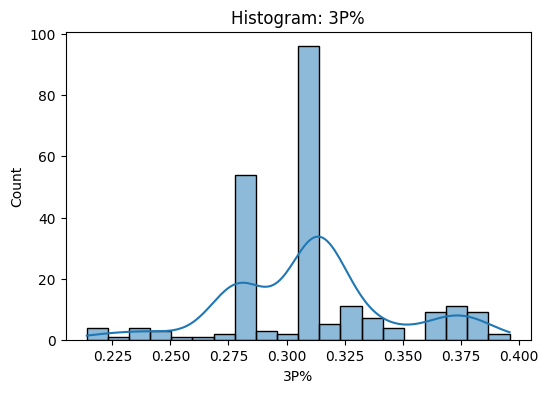

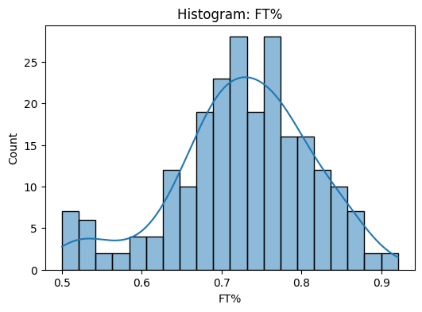

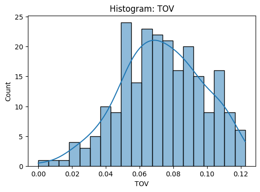

```
Top 5 players (unit normalization):
                  Player  Synthetic_Index
401       Flynn Robinson         0.703491
69        Devontae Cacok         0.621661
449           Earl Tatum         0.600642
0    Kareem Abdul-Jabbar         0.588795
252          Eddie Jones         0.584669

Top 5 players (standardization):
                  Player  Synthetic_Index
401       Flynn Robinson         1.174749
69        Devontae Cacok         0.775705
449           Earl Tatum         0.709151
0    Kareem Abdul-Jabbar         0.663099
252          Eddie Jones         0.643621

Top 5 players (ratio transformation):
                Player  Synthetic_Index
401     Flynn Robinson         1.526888
121        Vlade Divac         1.383170
69      Devontae Cacok         1.366591
479  Kermit Washington         1.339179
44          Jim Brewer         1.334621
```

```python
import pandas as pd
import numpy as np
import os
import matplotlib.pyplot as plt
import seaborn as sns


def load_lakers_data(filepath):
    df = pd.read_csv(filepath, encoding='cp1250', sep=',')
    return df

def classify_features():
    return {
        'stimulants': ['ORB', 'AST', 'STL', 'BLK', 'PTS', 'FG%', '3P%', 'FT%'],
        'destimulants': ['TOV'],
        'nominals': []
    }

def min_max_scaling(df, features):
    return (df[features] - df[features].min()) / (df[features].max() - df[features].min())

def standardization(df, features):
    return (df[features] - df[features].mean()) / df[features].std()

def ratio_transformation(df, features):
    return df[features].div(df[features].mean())

def compute_synthetic_index(df, weights=None):
    if weights is None:
        weights = np.ones(df.shape[1]) / df.shape[1]
    return df.dot(weights)

def preprocess_data(df, all_features):
    df = df[df['Yrs'] > 1]

    df = df[df['MP'].notna()]
    df[all_features] = df[all_features].fillna(df[all_features].median())
    #df.loc[:, all_features] = df[all_features].fillna(df[all_features].median())

    per_minute_features = ['ORB', 'AST', 'STL', 'BLK', 'TOV', 'PTS']
    for feature in per_minute_features:
        df[feature] = df[feature] / df['MP']
        #df.loc[:, feature] = df[feature] / df['MP']

    return df

def impute_outliers_IQR(df, features):

    for feature in features:
        q1 = df[feature].quantile(0.25)
        q3 = df[feature].quantile(0.75)
        IQR = q3 - q1

        lower_bound = q1 - 1.5 * IQR
        upper_bound = q3 + 1.5 * IQR
        mean_val = df[feature].mean()

        df.loc[df[feature] > upper_bound, feature] = mean_val
        df.loc[df[feature] < lower_bound, feature] = mean_val

    return df

def transform_destimulants(df, destimulants):
    for feature in destimulants:
        df[feature] = df[feature].max() - df[feature]
    return df

def plot_histograms(df, features, output_dir):
    for feature in features:
        plt.figure(figsize=(6, 4))
        sns.histplot(df[feature], kde=True, bins=20)
        plt.title(f'Histogram: {feature}')
        plt.show()
        plt.close()

def generate_rankings(df, all_features, method_dict):
    for name, method in method_dict.items():
        df_norm = method(df.copy(), all_features)
        df["Synthetic_Index"] = compute_synthetic_index(df_norm[all_features])
        ranking = df[["Player", "Synthetic_Index"]].sort_values(by="Synthetic_Index", ascending=False)
        output_file = f"ranking_lakers_{name}.csv"
        ranking.to_csv(output_file, index=False)
        print(f"Top 5 players ({name}):")
        print(ranking.head(5), "\n")

def main():
    filepath = "players1.csv"
    df = load_lakers_data(filepath)
    df.head()


    features = classify_features()
    all_features = features['stimulants'] + features['destimulants']

    df = preprocess_data(df, all_features)
    df = impute_outliers_IQR(df, all_features)
    df = transform_destimulants(df, features['destimulants'])

    plot_histograms(df, all_features, output_dir="plots/histograms")

    transformations = {
        'unit normalization': min_max_scaling,
        'standardization': standardization,
        'ratio transformation': ratio_transformation
    }

    generate_rankings(df, all_features, transformations)


if __name__ == "__main__":
    main()
```

```python
from IPython.core.display import HTML

HTML("""
    <style>
        @import url('https://fonts.googleapis.com/css2?family=Lora&display=swap');

        body, .rendered_html, .jp-RenderedHTMLCommon, .jp-Notebook, .jp-Cell {
            font-family: 'Lora', serif !important;
        }
    </style>
""")
```